# Lab 6: Building a spam filter

In this lab, you’ll get a chance to put to use what you know about exploratory data analysis in exploring a new dataset where the primary variable of interest – the response variable - is categorical. **You will be submitting the Rmd and html files as usual.**

**Resources** Please consult the slidedecks from Week 4 on the [Class Schedule](https://canvas.uw.edu/courses/1721011/pages/class-schedule) for help with the new functions on this lab. I am also assuming that you are familiar with the live-coding exercise from class on 4/17.

**Learning Objectives**

- Make and interpret bar charts
- Construct contingency tables
- Visualize associations with mosaic plots

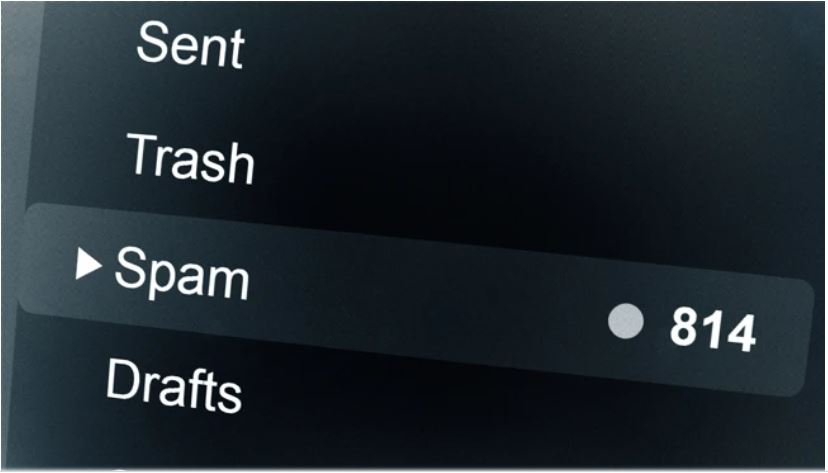

soscanhelp.com

Spam filters are designed to identify emails that attackers or marketers use to send unwanted or dangerous content. These filters work by analyzing incoming email for red flags that signal spam and then automatically moving those emails to a spam folder. In this lab we will examine how the email contents relate to whether or not an email is spam.

**Please read all the text in this lab, not just the exercises.**

## Getting started

Launch the RStudio image on JupyterHub by clicking [here](https://jupyter.rttl.uw.edu/2024-spring-stat-311-a/user-redirect/rstudio). Create a new lab report template to save your answers to the exercises. Be sure to personalize the header with the title of the lab and also add your name.

### Packages

In this assignment we will work with the **tidyverse** and **openintro** packages as usual. In addition, we will use the **janitor** package for creating tables and **ggridges** to make density ridge plots. Let’s go ahead and load them.

```r
library(tidyverse)    #umbrella suite of packages
library(openintro)    #data is from this package
library(janitor)      #for making tables
library(ggridges)     #for density ridge plots
```

## The Data

The `email` dataset in the **openintro** package contains information on all of the emails received by a single email account over a three month period from Jan - Mar 2012. Each email is a case or unit of observation, so we see that this email account received 3,921 emails. Twenty-one different variables were recorded on each email, some of which are numerical, others are categorical.

Of primary interest is the first column, a categorical variable indicating whether or not the email is `spam`. A value of “1” indicates the email is spam. This was created by actually reading through each email individually and deciding if it looked like spam or not. The subsequent columns were easier to create. `to_multiple` is TRUE if the email was addressed to more than one recipient and FALSE otherwise. `image` is the number of images attached in the email. It’s important that you have a full sense of what each of the variables mean, so you’ll want to start your exercises by reading about them in the [data set description](https://www.openintro.org/data/index.php?data=email).

```r
?email
```

One of your guiding questions throughout this lesson is: what characteristics of an email are associated with it being spam? Numerical and graphical summaries are a great way of starting to answer that question.

Load the `email` data frame and take a look at the contents, dimensions, variable types, what the values mean etc. **It is really important that you notice the variable types. Things like `fill` only work with variables that are encoded as `chr` or `fct`.**

A primary variable of interest in this dataframe is `spam` which takes the value 1 if an email is spam and 0 otherwise. We can use the `count` function to create a frequency table. This is done for you below; you do not need to type this.

```r
#just read this
email %>% count(spam)
```

```
## # A tibble: 2 × 2
##   spam      n
##   <fct> <int>
## 1 0      3554
## 2 1       367
```

Let’s begin by re-coding the values of the `spam` variable from 0, 1 so it takes more intuitive labels such as “no” and “yes” respectively.

1. Create and add a new variable called `Spam` to the `email` dataframe which takes the value “yes” when the value for `spam` is 1, and “no” otherwise. Then print the frequency distribution of the variable `Spam` you have just created.

   *Hint* I have provided partial code for you below. You will need to create a code chunk in your lab report containing this code with the blanks filled in.

   ```r
   email <- email %>%
                mutate(Spam = ifelse(___, ___, ___ ))
   ```

We will be using this recoded variable - `Spam` - in the remainder of this analysis.

## Analysis

### Are longer messages more likely to be spam?

Let’s start with examining if there is an association between spam and the length of an email? You could imagine a story either way:

- *Spam is more likely to be a short message tempting me to click on a link*, or
- *My normal email is likely shorter since I exchange brief emails with my friends all the time*.

Here, you’ll use the `email` dataset to settle that question by comparing the number of characters in the email, called `num_char`, between messages marked as spam and those that are not. (Note: The number of characters is measured in the thousands. So a value of 11.37 implies there were 11,370 characters in that email)

2. Construct a density ridge plot to examine the distribution of `num_char` by whether or not an email is classified as `Spam`. Then calculate the median number of characters for spam and non-spam messages. Be sure to show your code and output (without messages or warnings) and label your plot. Then report what you learn about whether spam messages tend to be longer or shorter in one or two sentences.

### Are messages with the word “winner” more likely to be spam?

It is reasonable to think that spam messages might contain offers of prize money, and so a message with the word “winner” is more likely to be spam. So we will now turn our attention to the categorical variable called `winner`. Read more about this variable by pulling up the help file with `?email`.

A **segmented bar chart** is a popular graphic for exploring the association between categorical variables.

For example, if we are curious about whether the emails written using HTML tend to be spam, we would make the following bar plot.

You do not need to type this. Just read the code and see the resulting output.

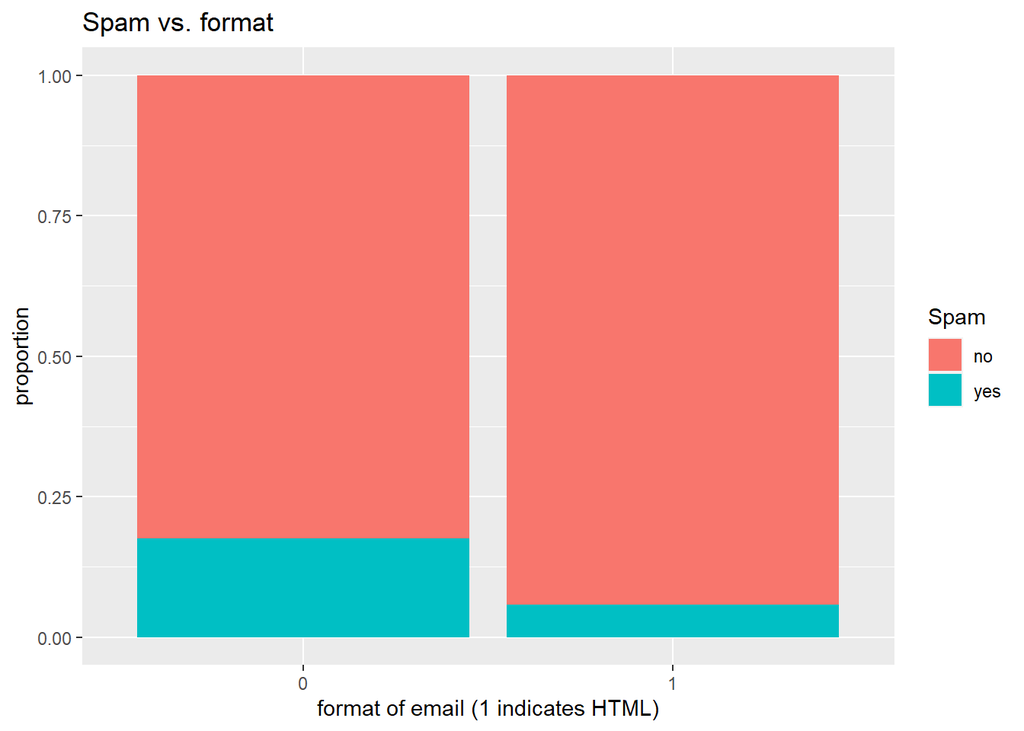

```r
ggplot(data=email,
       mapping=aes(x = format,
                   fill = Spam ))+
  geom_bar(position="fill") +
  labs(
      title = "Spam vs. format",
      x =  "format of email (1 indicates HTML)",
      y = "proportion")
```

Note that the values of the variable `format` are placed on the $x$ axis so we can more easily visualize its impact on the response `Spam`. Interestingly, there appears to be a *negative* association between the two variables. That is, a smaller fraction of emails written in HTML are spam.

3. Write code to create a segmented bar chart to study the relationship between an email containing the word `winner` and being `Spam`. What can we conclude about the association between the two from the bar chart? Be sure to show your code and output (without messages or warnings). Then write a couple of sentences to describe your understanding of how they are related.

### Are messages with a number more likely to be spam?

Next we examine whether emails with a number are more likely to be spam. The column `number` is a categorical variable which describes whether there was no number, a small number (under 1 million) or a big number.

Segmented bar charts are useful for displaying relationships between categorical variables, but tables can also be a very effective way of conveying this information. For example, the following code creates a tabular representation of the frequencies for `Spam` and `format`.

```r
## just read the code

email %>%
   tabyl(format, Spam) %>%
   adorn_totals(where="row") %>%
   adorn_percentages(denominator="row") %>%
   adorn_pct_formatting(digits=2) %>%
   adorn_ns() %>%
   adorn_title()
```

```
##                   Spam
##  format             no          yes
##       0 82.51%   (986) 17.49% (209)
##       1 94.20% (2,568)  5.80% (158)
##   Total 90.64% (3,554)  9.36% (367)
```

We first specify the two categorical variables of interest in the `tabyl()` function, taking care to name the explanatory variable `format` first. This ensures that the values of this variable will correspond to the rows. While this is entirely optional, having the explanatory variable along the rows makes it easier to study the impact it has on the response: the column variable.

Once the cross tabs are created with `tabyl`, the result is passed on to various enhancements to make the table more readable and functional.

- `adorn_totals` augments the table with a totals row (by default).
- `adorn_percentages` returns row proportions, that is percentages calculated for each cell where the denominator is taken as total for the row in which the cell lies. (This explains why the row proportions add to 1.)
- `adorn_pct_formatting` formats the number of digits after the decimal
- `adorn_ns` adds back the underlying frequencies to the table
- `adorn_title` is self explanatory.

If `format` is not related to whether an email is spam or not, then the proportion of spam/not spam in each row should be around 9.36%, the overall rate of spam emails. Clearly, this is not the case. The table shows these variables are associated.

Now it’s your turn.

4. Write code to create a contingency table of the frequencies for `Spam` and `number`. Be sure to show your code and also the output (without messages or warnings). Then write a couple of sentences describing how the two variables are related. Be sure to mention what %’s of spam we should see if the variables are unrelated as well as how the data is deviating from these expectations.

A mosaic plot can enable us to quantify the strength of associations within a contingency table format. For example, the following code creates a mosaicplot of the association between `Spam` and `format`.

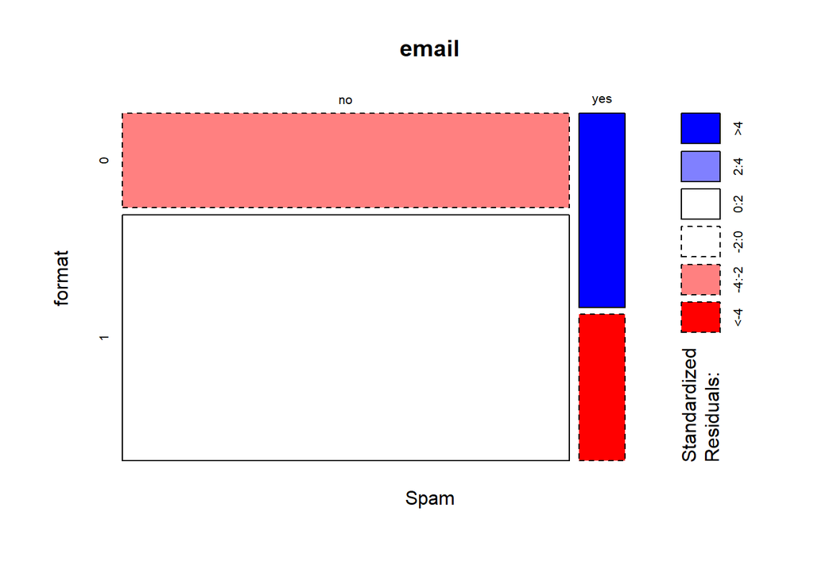

```r
## just read the code
mosaicplot(Spam ~ format, data=email, shade=TRUE)
```

The variables are specified using what’s known as a formula type interface with the response variable on the left hand side of the tilda $\sim$ and the explanatory variable on the right.

The function `mosaicplot` should create a graph with blocks representing the 4 combinations of `Spam` and `format`. The area of each block is proportional to the frequency in the corresponding cell.

When we set `shade=TRUE`, the cells are filled with one of three colors: red, white or blue. The presence of red or blue filled cells in a mosaicplot indicate a **statistically meaningful deviation** from expected in that cell.

Cells that are **much more** populated than expected are colored blue and those that are **much less** populated than expected are colored red. The cells that don’t deviate dramatically are white.

Now it’s your turn to examine the relationship between `number` and `Spam`.

5. Create a mosaic plot for your table from exercise 4. Be sure to show your code and output (without messages or warnings). Also write a sentence on what you learn from the plot

## Conclusion

Congratulations! This concludes lab 6. Be sure to turn in the `.Rmd` and `.html` files in CANVAS by the due date. Don’t forget to **quit** out of the server as well!